# IE582FinalExam

Tümay Kır

2/24/2021

# 1 Multiple Instances Learning

Needed libraries are imported below.

```r
library(ggplot2)
library(factoextra)
library(cluster)
library(dplyr)
library(data.table)
library(caret)
library(glmnet)
library(rpart)
library(ranger)
library(ROSE)
library(randomForest)
library(ROCR)
library(pROC)
library(plotROC)
```

## 1.1 Introduction

In this assignment, euclidean and manhattan distances are used as metrics.K-medoids technique is used for clustering.K-medoids clustering is a technique in which we place each observation in a dataset into one of K clusters.The end goal is to have K clusters in which the observations within each cluster are quite similar to each other while the observations in different clusters are quite different from each other.

After all, I will apply Decision Tree and Random Forest algorithms for classification.

The dataset named Musk1 is read and then scaled.The dataset `data` differs from `data_musk`, since it doesn’t include the bag_id and bag_class information (first two columns).

```r
data_musk<-read.csv("C:/Users/tumay/Desktop/Musk1.csv",header = FALSE)
data<-data_musk
data <- na.omit(data)
data <- scale(data[,-c(1,2)])
head(data)
```

```
##         V3         V4         V5        V6         V7        V8        V9
## 1 0.180723 -0.8815999 -0.4301752 -1.203764 -0.1637934 0.2255951 0.3718827
## 2 0.180723 -0.8023368 -0.9072433 -1.071341 -0.1637934 0.7037235 0.6158746
## 3 0.180723 -0.8023368 -0.9072433 -1.203764 -0.1637934 0.2255951 0.6158746
## 4 0.180723 -0.8815999 -0.4446318 -1.071341 -0.1637934 0.7037235 0.3718827
## 5 0.180723 -0.8815999 -0.3289789 -1.203764 -0.1637934 0.2147286 0.3812670
## 6 0.180723 -0.8023368 -0.9072433 -1.071341 -0.1637934 0.7037235 0.6158746
##         V10       V11       V12       V13        V14         V15       V16
## 1 -1.263585 0.6545626 0.6772360 -1.534785 -1.7107828  0.08492251 -2.058397
## 2 -2.345572 0.4780699 1.1188121 -2.571670 -0.5414575 -0.53372164 -1.998322
## 3 -2.226817 0.4780699 0.6634368 -2.047653 -0.5414575  0.06983363 -1.914217
## 4 -1.355949 0.6545626 1.1188121 -2.304087 -1.7107828 -0.53372164 -1.986307
## 5 -1.250390 0.6545626 0.6634368 -1.545935 -1.7107828  0.06983363 -2.058397
## 6 -2.345572 0.4780699 1.1326113 -2.560521 -0.5294026 -0.51863276 -1.986307
##         V17        V18        V19         V20        V21         V22        V23
```

[output cut: 153 more lines]

After scaling the data, Euclidean and Manhattan distances are created.

```r
euclidean <- data %>% dist("euclidean")
manhattan <- data %>% dist("manhattan")
euclidean<-as.data.table(as.matrix(euclidean))
manhattan<-as.data.table(as.matrix(manhattan))
```

## 1.2 Analysis

### 1.2.1 K-medoids Clustering

To find the optimal k value, I tried different methods by searching various websites about this subject. First, I used the fviz_nbclust() function to create a plot of the number of clusters vs. the total within sum of squares:

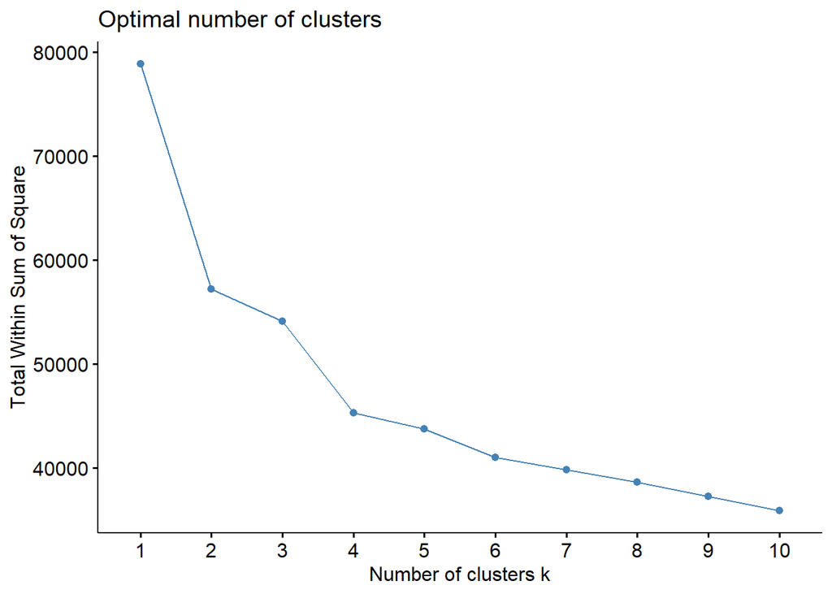

```r
fviz_nbclust(data, pam, method = "wss")
```

The point where the plot bends is typically the optimal number of clusters. Beyond this number, overfitting is likely to occur.

For this plot it appear that there is a bit of an elbow or “bend” at k = 4 clusters.

**Another way to determine the optimal number of clusters** is to use a metric known as the gap statistic, which compares the total intra-cluster variation for different values of k with their expected values for a distribution with no clustering.

We can calculate the gap statistic for each number of clusters using the clusGap() function from the cluster package along with a plot of clusters vs. gap statistic using the fviz_gap_stat() function:

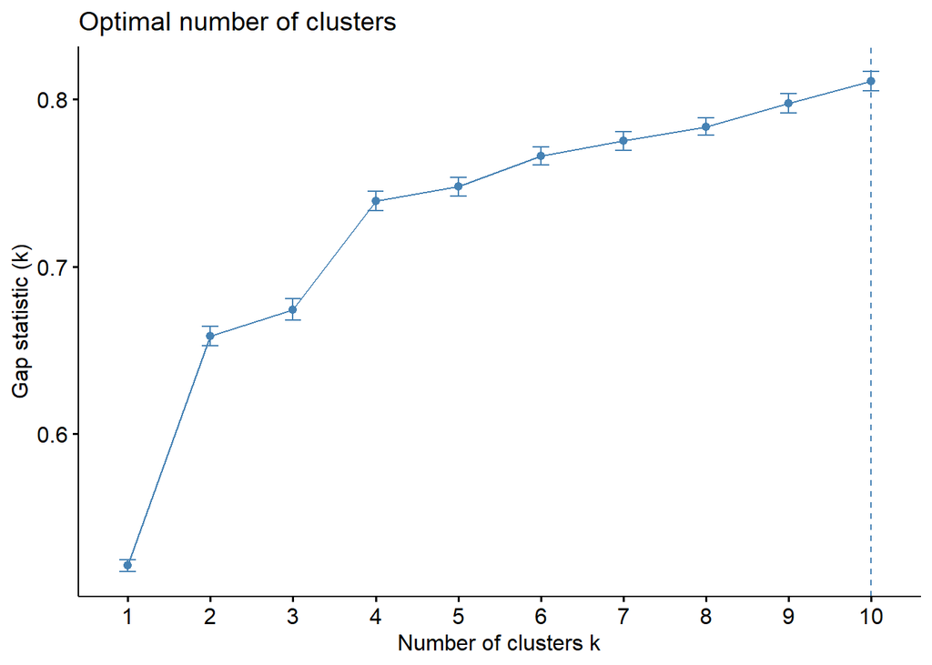

```r
gap_stat <- clusGap(data,
                    FUN = pam,
                    K.max = 10, #max clusters to consider
                    B = 50) #total bootstrapped iterations
#plot number of clusters vs. gap statistic
fviz_gap_stat(gap_stat)
```

From the plot we can see that gap statistic is highest at k = 10 clusters, which doesn’t match the elbow method we used earlier(which doesn’t make sense).

Then, I choose the optimal value for k as 4:

```r
set.seed(1)

#perform k-medoids clustering with k = 4 clusters
kmed <- pam(data, k = 4)

#view results
kmed
```

```
## Medoids:
##      ID         V3         V4         V5         V6         V7         V8
## 12   12  0.1254375  0.2847002  0.2637420 -1.2037636 -0.1637934  0.2690613
## 90   90  1.0652899 -0.5871941  0.4805911  0.1601865 -0.1637934 -0.9479927
## 69   69  0.2360084  0.1714671  0.8420063 -0.9389189 -0.1637934  0.8558552
## 108 108 -1.0355565 -0.8249834 -0.9795263  0.2263977 -0.1637934 -0.2959994
##             V9        V10        V11        V12        V13        V14
## 12   0.4375728 -2.2664022  0.8206733  0.7048345 -1.7800698 -1.6143436
## 90   0.6346433 -0.1552072  0.5611253 -0.6474922  0.5501335  0.3747149
## 69  -1.4205197  0.1350821 -1.4841128  0.6634368  0.3605955 -0.1557007
## 108  0.5971060 -0.1156223  0.4469242 -0.7440870  0.5278350  0.2782757
##            V15         V16         V17        V18        V19        V20
## 12  0.06983363 -2.15451667 -2.32539471 -0.6091391  0.1237210 -0.4516571
## 90  0.23581133 -0.01585169  0.04779095 -0.2333937  0.6940542 -0.2222949
## 69  0.03965586  0.27250764  0.04779095  0.5494093 -1.5181471 -0.1764225
```

[output cut: 182 more lines]

visualization of the clusters on a scatterplot that displays the first two principal components on the axes using the fivz_cluster() function:

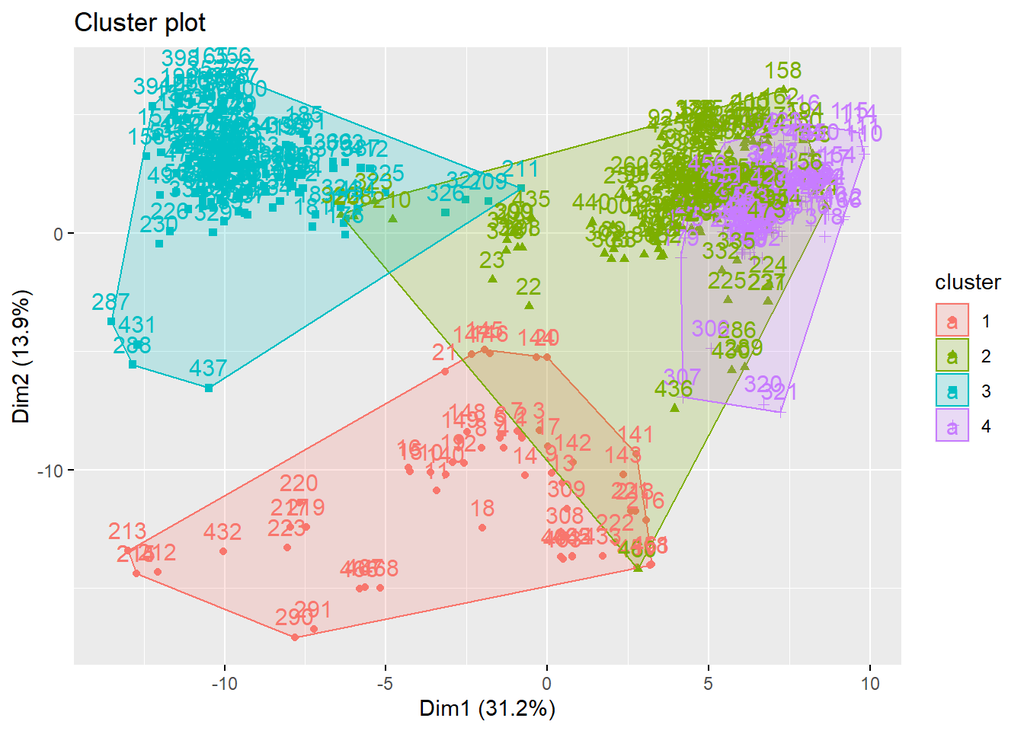

```r
fviz_cluster(kmed, data = data)
```

### 1.2.2 Euclidean Distance

I created euclidean matrix by calculating the mean of the data according to the variable `bag_id`.

```r
euc_kmed <- pam(data, k=4, metric='euclidean',stand = FALSE)
euc_kmed$id.med
```

```
## [1]  12  90  69 108
```

```r
cluster_dist<-cbind(euclidean[,12],euclidean[,90],euclidean[,69],euclidean[,108])
all_data <- cbind(data_musk[,1:2],cluster_dist)
mean_data<-all_data%>%group_by(V2)%>%summarise_at(vars(-V1), funs(mean(., na.rm=TRUE)))
mean_data[,"bag_class"]<-1
mean_data$bag_class <- ifelse(mean_data$V2 > 47,"0","1")
mean_data<-mean_data[,c(ncol(mean_data),1:(ncol(mean_data)-1))]
colnames(mean_data)[2] <- "bag_id"
colnames(mean_data)[3] <- "c1"
colnames(mean_data)[4] <- "c2"
colnames(mean_data)[5] <- "c3"
colnames(mean_data)[6] <- "c4"
head(mean_data)
```

```
## # A tibble: 6 x 6
##   bag_class bag_id    c1    c2    c3    c4
##   <chr>      <int> <dbl> <dbl> <dbl> <dbl>
## 1 1              1  8.17  16.7  18.9  16.4
## 2 1              2  9.67  16.1  18.6  17.5
## 3 1              3  9.72  16.4  18.7  18.2
## 4 1              4  5.87  16.7  19.1  17.5
## 5 1              5 15.4   20.1  21.9  21.8
## 6 1              6 10.1   17.2  19.8  18.8
```

### 1.2.3 Manhattan Distance

I created manhattan matrix by calculating the mean of the data according to the variable `bag_id`.

```r
man_kmed <- pam(data, k=4, metric='manhattan',stand = FALSE)
man_kmed$id.med
```

```
## [1]  12  52  58 108
```

```r
cluster_dist_man<-cbind(manhattan[,12],manhattan[,52],manhattan[,58],manhattan[,108])
all_data_man <- cbind(data_musk[,1:2],cluster_dist_man)
mean_data_man<-all_data_man%>%group_by(V2)%>%summarise_at(vars(-V1), funs(mean(., na.rm=TRUE)))
mean_data_man[,"bag_class"]<-1
mean_data_man$bag_class <- ifelse(mean_data_man$V2 > 47,"0","1")
mean_data_man<-mean_data_man[,c(ncol(mean_data_man),1:(ncol(mean_data_man)-1))]
colnames(mean_data_man)[2] <- "bag_id"
colnames(mean_data_man)[3] <- "c1"
colnames(mean_data_man)[4] <- "c2"
colnames(mean_data_man)[5] <- "c3"
colnames(mean_data_man)[6] <- "c4"
head(mean_data_man)
```

```
## # A tibble: 6 x 6
##   bag_class bag_id    c1    c2    c3    c4
##   <chr>      <int> <dbl> <dbl> <dbl> <dbl>
## 1 1              1  65.3  158.  163.  154.
## 2 1              2  79.2  151.  174.  168.
## 3 1              3  83.2  154.  191.  178.
## 4 1              4  47.9  173.  164.  174.
## 5 1              5 102.   173.  213.  196.
## 6 1              6  80.6  168.  197.  186.
```

### 1.2.4 Decision Tree (Euclidean)

When decision tree classification method is applied for euclidean distance, the best result which has the highest accuracy value is 0.7383333 for cp=0.01.

```r
grid_dt_euc <- expand.grid(cp=c(0.005,0.01,0.003,0.007,0.1,0.03))
control_euc<-trainControl(method="cv", number=10,  allowParallel=TRUE, classProbs = TRUE)
set.seed(123)
levels(mean_data$bag_class) <- c("one", "zero")

mean_data<-mean_data  %>%
  mutate(bag_class = factor(bag_class,
                        labels = make.names(levels(bag_class))))

dt_model_euc <- train(x=as.matrix(mean_data[,3:6]),y=as.matrix(mean_data$bag_class), method ="rpart", tuneGrid = grid_dt_euc,trControl=control_euc, control = rpart.control(minbucket=c(5)))
dt_model_euc
```

```
## CART
##
## 92 samples
##  4 predictor
##  2 classes: 'one', 'zero'
##
## No pre-processing
## Resampling: Cross-Validated (10 fold)
## Summary of sample sizes: 82, 82, 84, 83, 83, 83, ...
## Resampling results across tuning parameters:
##
##   cp     Accuracy   Kappa
##   0.003  0.7383333  0.4692362
##   0.005  0.7383333  0.4692362
##   0.007  0.7383333  0.4692362
##   0.010  0.7383333  0.4692362
##   0.030  0.7161111  0.4166046
##   0.100  0.6538889  0.2990185
##
## Accuracy was used to select the optimal model using the largest value.
## The final value used for the model was cp = 0.01.
```

### 1.2.5 Decision Tree (Manhattan)

When decision tree classification method is applied for manhattan distance, the best result which has the highest accuracy value is 0.7161111 for cp=0.03.

```r
grid_dt_man <- expand.grid(cp=c(0.005,0.01,0.003,0.007,0.1,0.03))
control_man<-trainControl(method="cv", number=10,  allowParallel=TRUE, classProbs = TRUE)
set.seed(123)
levels(mean_data_man$bag_class) <- c("one", "zero")


mean_data_man<-mean_data_man  %>%
  mutate(bag_class = factor(bag_class,
                            labels = make.names(levels(bag_class))))
dt_model_man <- train(x=as.matrix(mean_data_man[,3:6]),y=as.matrix(mean_data_man$bag_class), method ="rpart", tuneGrid = grid_dt_man,trControl=control_man, control = rpart.control(minbucket=c(5)))
dt_model_man
```

```
## CART
##
## 92 samples
##  4 predictor
##  2 classes: 'one', 'zero'
##
## No pre-processing
## Resampling: Cross-Validated (10 fold)
## Summary of sample sizes: 82, 82, 84, 83, 83, 83, ...
## Resampling results across tuning parameters:
##
##   cp     Accuracy   Kappa
##   0.003  0.7047222  0.4209724
##   0.005  0.7047222  0.4209724
##   0.007  0.7047222  0.4209724
##   0.010  0.7047222  0.4209724
##   0.030  0.7161111  0.4417416
##   0.100  0.6494444  0.2960782
##
## Accuracy was used to select the optimal model using the largest value.
## The final value used for the model was cp = 0.03.
```

### 1.2.6 Random Forest (Euclidean)

When random forest classification method is applied for euclidean distance, the best result which has the highest accuracy value is 0.7916667 for mtry=3.

```r
grid_rf_euc <- expand.grid(mtry = c(1:4) ,min.node.size=5, splitrule = "gini")
set.seed(123)
rf_model_euc <- train(x=as.matrix(mean_data[,3:6]),y=as.matrix(mean_data$bag_class), method="ranger", tuneGrid= grid_rf_euc, trControl= control_euc)
rf_model_euc
```

```
## Random Forest
##
## 92 samples
##  4 predictor
##  2 classes: 'one', 'zero'
##
## No pre-processing
## Resampling: Cross-Validated (10 fold)
## Summary of sample sizes: 82, 82, 84, 83, 83, 83, ...
## Resampling results across tuning parameters:
##
##   mtry  Accuracy   Kappa
##   1     0.7805556  0.5598816
##   2     0.7694444  0.5342771
##   3     0.7916667  0.5793615
##   4     0.7805556  0.5551308
##
## Tuning parameter 'splitrule' was held constant at a value of gini
##
## Tuning parameter 'min.node.size' was held constant at a value of 5
## Accuracy was used to select the optimal model using the largest value.
## The final values used for the model were mtry = 3, splitrule = gini
##  and min.node.size = 5.
```

### 1.2.7 Random Forest (Manhattan)

When random forest classification method is applied for manhattan distance, the best result which has the highest accuracy value is 0.7619444 for mtry=2.

```r
grid_rf_man <- expand.grid(mtry = c(1:4) ,min.node.size=5, splitrule = "gini")
set.seed(123)
rf_model_man <- train(x=as.matrix(mean_data_man[,3:6]),y=as.matrix(mean_data_man$bag_class), method="ranger", tuneGrid= grid_rf_man, trControl= control_man)
rf_model_man
```

```
## Random Forest
##
## 92 samples
##  4 predictor
##  2 classes: 'one', 'zero'
##
## No pre-processing
## Resampling: Cross-Validated (10 fold)
## Summary of sample sizes: 82, 82, 84, 83, 83, 83, ...
## Resampling results across tuning parameters:
##
##   mtry  Accuracy   Kappa
##   1     0.7519444  0.5032083
##   2     0.7619444  0.5198311
##   3     0.7108333  0.4154226
##   4     0.7408333  0.4743251
##
## Tuning parameter 'splitrule' was held constant at a value of gini
##
## Tuning parameter 'min.node.size' was held constant at a value of 5
## Accuracy was used to select the optimal model using the largest value.
## The final values used for the model were mtry = 2, splitrule = gini
##  and min.node.size = 5.
```

## 1.3 Comparison

```r
# collect resamples
results <- resamples(list(dt_euc=dt_model_euc, dt_man=dt_model_man,rf_euc=rf_model_euc, rf_man=rf_model_man))
# summarize the distributions
summary(results)
```

```
##
## Call:
## summary.resamples(object = results)
##
## Models: dt_euc, dt_man, rf_euc, rf_man
## Number of resamples: 10
##
## Accuracy
##             Min.   1st Qu.    Median      Mean   3rd Qu.      Max. NA's
## dt_euc 0.5555556 0.6750000 0.7638889 0.7383333 0.7944444 0.8888889    0
## dt_man 0.3333333 0.6750000 0.7250000 0.7161111 0.7777778 0.9000000    0
## rf_euc 0.5555556 0.7569444 0.7888889 0.7916667 0.8666667 1.0000000    0
## rf_man 0.4444444 0.6750000 0.7888889 0.7619444 0.8562500 1.0000000    0
##
## Kappa
##               Min.   1st Qu.    Median      Mean   3rd Qu.      Max. NA's
## dt_euc  0.05263158 0.3560976 0.5131579 0.4692362 0.5875000 0.7804878    0
## dt_man -0.28571429 0.3790698 0.4500000 0.4417416 0.5714286 0.8000000    0
## rf_euc  0.14285714 0.5125000 0.5750000 0.5793615 0.7353659 1.0000000    0
## rf_man -0.09756098 0.3307692 0.5750000 0.5198311 0.7125000 1.0000000    0
```

**Random forest with euclidean distance** has the highest mean of accuracy, 0.7916667.

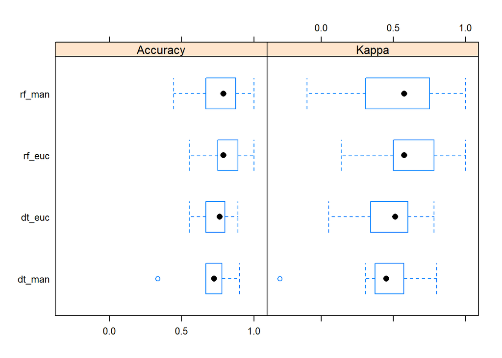

```r
# boxplots of results
bwplot(results)
```

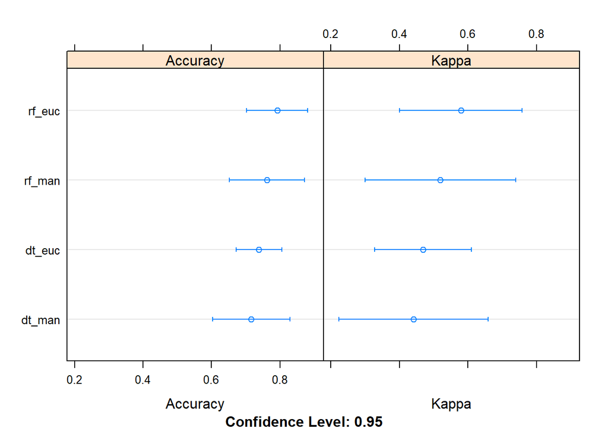

```r
# dot plots of results
dotplot(results)
```

### 1.3.1 Predictions

```r
pred_dt_1=predict(dt_model_euc$finalModel)
pred_dt_2=predict(dt_model_man$finalModel)
pred_rf_1=predict(rf_model_euc$finalModel, data=mean_data[,3:6])
pred_rf_2=predict(rf_model_man$finalModel,data=mean_data_man[,3:6])
```

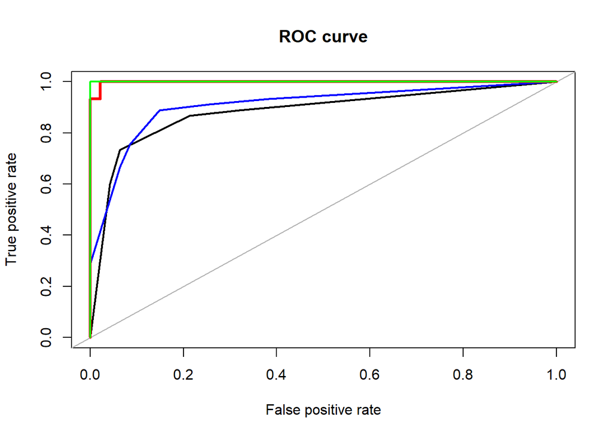

```r
roc.curve(mean_data$bag_class,pred_dt_1[,1], add.roc = FALSE)
roc.curve(mean_data_man$bag_class,pred_dt_2[,1], add.roc = TRUE, col="blue",lwd=2)
roc.curve(mean_data$bag_class,pred_rf_1$predictions[,1], add.roc = TRUE, col="red",lwd=3)
roc.curve(mean_data_man$bag_class,pred_rf_2$predictions[,1], add.roc = TRUE, col="green",lwd=2)
```

## 1.4 Conclusion

If we analyse the ROC curve results, we can see that;

Area under the curve for dt_1 (AUC): 0.883  
Area under the curve dt_2 (AUC): 0.908  
Area under the curve rf_1 (AUC): 0.999  
Area under the curve rf_2 (AUC): 1.000

Obviously, even if random forest has the highest accuracy, there are **overfitting** problems for especially random forest models.In other words, the model remembers a huge number of examples instead of learning to notice features.